# Analysis NAD captureSeq R1

## 1. Data import

First, we import the counts table from replicate 1.

```r
countsTable <- read.delim("final_counts_table_ONTrun_061_unclassified.tsv", comment.char="#", stringsAsFactors=TRUE)
```

We adjust the column names to a more comprehensive style

```r
colnames(countsTable) <- c("Geneid", "Chr", "Start", "End", "Strand", "Length", "T0_p", "T1_p", "T4_p", "T7_p", "T10_p", "T20_p", "T0_n", "T1_n", "T4_n", "T7_n", "T10_n", "T20_n")
head(countsTable)
```

```
##       Geneid      Chr Start  End Strand Length T0_p T1_p T4_p T7_p T10_p T20_p
## 1 gene-b0001 U00096.3   190  255      +     66    7    2    1    0     1     0
## 2 gene-b0002 U00096.3   337 2799      +   2463    3    1    0    0     0     0
## 3 gene-b0003 U00096.3  2801 3733      +    933    0    0    0    0     0     0
## 4 gene-b0004 U00096.3  3734 5020      +   1287    0    0    0    0     0     1
## 5 gene-b0005 U00096.3  5234 5530      +    297    0    0    0    0     0     0
## 6 gene-b0006 U00096.3  5683 6459      -    777    0    0    0    0     0     0
##   T0_n T1_n T4_n T7_n T10_n T20_n
## 1    0    0    0    0     0     0
## 2    0    0    0    0     0     0
## 3    0    0    0    0     0     0
## 4    0    0    0    0     0     0
## 5    0    0    0    0     0     0
## 6    0    0    0    0     0     0
```

```r
tail(countsTable)
```

```
##           Geneid         Chr  Start    End Strand Length T0_p T1_p T4_p T7_p
## 4778 gene-T4p274 NC_000866.4 166815 166913      -     99    0    7   17    1
## 4779 gene-T4p275 NC_000866.4 166910 166996      -     87    0    9   10    0
## 4780 gene-T4p276 NC_000866.4 167103 167660      -    558    0    0    0    0
## 4781 gene-T4p277 NC_000866.4 167743 167937      -    195    0    0    0    1
## 4782 gene-T4p278 NC_000866.4 167965 168903      -    939    0    0    0    1
## 4783       qbeta       Qbeta      1    100      +    100 1698  786 1277 1555
##      T10_p T20_p T0_n T1_n T4_n T7_n T10_n T20_n
## 4778     3     0    0    0    4    0     0     0
## 4779     0     0    0    0    0    0     0     0
## 4780     3     1    0    0    0    2     1     1
## 4781     0     0    0    0    0    0     0     0
## 4782     1     0    0    0    0    3     2     0
## 4783  1227  1068   10    5    7   10     7    10
```

# 2. Data normalization

Now, we add a pseudocount (pse) to each count for each gene

```r
pse <- 0.1
countsTable_pse <- countsTable
countsTable_pse[,7:18] <- countsTable[,7:18]+pse
head(countsTable_pse)
```

```
##       Geneid      Chr Start  End Strand Length T0_p T1_p T4_p T7_p T10_p T20_p
## 1 gene-b0001 U00096.3   190  255      +     66  7.1  2.1  1.1  0.1   1.1   0.1
## 2 gene-b0002 U00096.3   337 2799      +   2463  3.1  1.1  0.1  0.1   0.1   0.1
## 3 gene-b0003 U00096.3  2801 3733      +    933  0.1  0.1  0.1  0.1   0.1   0.1
## 4 gene-b0004 U00096.3  3734 5020      +   1287  0.1  0.1  0.1  0.1   0.1   1.1
## 5 gene-b0005 U00096.3  5234 5530      +    297  0.1  0.1  0.1  0.1   0.1   0.1
## 6 gene-b0006 U00096.3  5683 6459      -    777  0.1  0.1  0.1  0.1   0.1   0.1
##   T0_n T1_n T4_n T7_n T10_n T20_n
## 1  0.1  0.1  0.1  0.1   0.1   0.1
## 2  0.1  0.1  0.1  0.1   0.1   0.1
## 3  0.1  0.1  0.1  0.1   0.1   0.1
## 4  0.1  0.1  0.1  0.1   0.1   0.1
## 5  0.1  0.1  0.1  0.1   0.1   0.1
## 6  0.1  0.1  0.1  0.1   0.1   0.1
```

```r
tail(countsTable_pse)
```

```
##           Geneid         Chr  Start    End Strand Length   T0_p  T1_p   T4_p
## 4778 gene-T4p274 NC_000866.4 166815 166913      -     99    0.1   7.1   17.1
## 4779 gene-T4p275 NC_000866.4 166910 166996      -     87    0.1   9.1   10.1
## 4780 gene-T4p276 NC_000866.4 167103 167660      -    558    0.1   0.1    0.1
## 4781 gene-T4p277 NC_000866.4 167743 167937      -    195    0.1   0.1    0.1
## 4782 gene-T4p278 NC_000866.4 167965 168903      -    939    0.1   0.1    0.1
## 4783       qbeta       Qbeta      1    100      +    100 1698.1 786.1 1277.1
##        T7_p  T10_p  T20_p T0_n T1_n T4_n T7_n T10_n T20_n
## 4778    1.1    3.1    0.1  0.1  0.1  4.1  0.1   0.1   0.1
## 4779    0.1    0.1    0.1  0.1  0.1  0.1  0.1   0.1   0.1
## 4780    0.1    3.1    1.1  0.1  0.1  0.1  2.1   1.1   1.1
## 4781    1.1    0.1    0.1  0.1  0.1  0.1  0.1   0.1   0.1
## 4782    1.1    1.1    0.1  0.1  0.1  0.1  3.1   2.1   0.1
## 4783 1555.1 1227.1 1068.1 10.1  5.1  7.1 10.1   7.1  10.1
```

We normalize the counts per gene and sample as the fraction of reads using all reads for all genes per sample.

```r
normalize_counts <- function(x){
  df <- x
  normValues <- colSums(x)
  i <- 1
  while(i<=length(normValues)){
    df[,i] <- x[,i]/normValues[i]
    i <- i+1
  }
  return(df)
}

df_normalized <- normalize_counts(countsTable_pse[,7:18])
head(df_normalized)
```

```
##           T0_p         T1_p         T4_p         T7_p        T10_p        T20_p
## 1 5.025019e-04 1.225755e-04 7.483859e-05 7.788587e-06 5.982065e-05 7.974291e-06
## 2 2.194022e-04 6.420621e-05 6.803508e-06 7.788587e-06 5.438241e-06 7.974291e-06
## 3 7.077491e-06 5.836928e-06 6.803508e-06 7.788587e-06 5.438241e-06 7.974291e-06
## 4 7.077491e-06 5.836928e-06 6.803508e-06 7.788587e-06 5.438241e-06 8.771720e-05
## 5 7.077491e-06 5.836928e-06 6.803508e-06 7.788587e-06 5.438241e-06 7.974291e-06
## 6 7.077491e-06 5.836928e-06 6.803508e-06 7.788587e-06 5.438241e-06 7.974291e-06
##           T0_n        T1_n         T4_n         T7_n        T10_n        T20_n
## 1 1.022777e-05 7.29698e-06 7.162144e-06 1.132593e-05 1.389217e-05 1.037743e-05
## 2 1.022777e-05 7.29698e-06 7.162144e-06 1.132593e-05 1.389217e-05 1.037743e-05
## 3 1.022777e-05 7.29698e-06 7.162144e-06 1.132593e-05 1.389217e-05 1.037743e-05
## 4 1.022777e-05 7.29698e-06 7.162144e-06 1.132593e-05 1.389217e-05 1.037743e-05
## 5 1.022777e-05 7.29698e-06 7.162144e-06 1.132593e-05 1.389217e-05 1.037743e-05
## 6 1.022777e-05 7.29698e-06 7.162144e-06 1.132593e-05 1.389217e-05 1.037743e-05
```

We create a table of counts with normalized reads in a rearranged setting.

```r
normCounts <- data.frame(cbind(countsTable_pse[,1:6], df_normalized[,c(1,7,2,8,3,9,4,10,5,11,6,12)]))
head(normCounts)
```

```
##       Geneid      Chr Start  End Strand Length         T0_p         T0_n
## 1 gene-b0001 U00096.3   190  255      +     66 5.025019e-04 1.022777e-05
## 2 gene-b0002 U00096.3   337 2799      +   2463 2.194022e-04 1.022777e-05
## 3 gene-b0003 U00096.3  2801 3733      +    933 7.077491e-06 1.022777e-05
## 4 gene-b0004 U00096.3  3734 5020      +   1287 7.077491e-06 1.022777e-05
## 5 gene-b0005 U00096.3  5234 5530      +    297 7.077491e-06 1.022777e-05
## 6 gene-b0006 U00096.3  5683 6459      -    777 7.077491e-06 1.022777e-05
##           T1_p        T1_n         T4_p         T4_n         T7_p         T7_n
## 1 1.225755e-04 7.29698e-06 7.483859e-05 7.162144e-06 7.788587e-06 1.132593e-05
## 2 6.420621e-05 7.29698e-06 6.803508e-06 7.162144e-06 7.788587e-06 1.132593e-05
## 3 5.836928e-06 7.29698e-06 6.803508e-06 7.162144e-06 7.788587e-06 1.132593e-05
## 4 5.836928e-06 7.29698e-06 6.803508e-06 7.162144e-06 7.788587e-06 1.132593e-05
## 5 5.836928e-06 7.29698e-06 6.803508e-06 7.162144e-06 7.788587e-06 1.132593e-05
## 6 5.836928e-06 7.29698e-06 6.803508e-06 7.162144e-06 7.788587e-06 1.132593e-05
##          T10_p        T10_n        T20_p        T20_n
## 1 5.982065e-05 1.389217e-05 7.974291e-06 1.037743e-05
## 2 5.438241e-06 1.389217e-05 7.974291e-06 1.037743e-05
## 3 5.438241e-06 1.389217e-05 7.974291e-06 1.037743e-05
## 4 5.438241e-06 1.389217e-05 8.771720e-05 1.037743e-05
## 5 5.438241e-06 1.389217e-05 7.974291e-06 1.037743e-05
## 6 5.438241e-06 1.389217e-05 7.974291e-06 1.037743e-05
```

```r
tail(normCounts)
```

```
##           Geneid         Chr  Start    End Strand Length         T0_p
## 4778 gene-T4p274 NC_000866.4 166815 166913      -     99 7.077491e-06
## 4779 gene-T4p275 NC_000866.4 166910 166996      -     87 7.077491e-06
## 4780 gene-T4p276 NC_000866.4 167103 167660      -    558 7.077491e-06
## 4781 gene-T4p277 NC_000866.4 167743 167937      -    195 7.077491e-06
## 4782 gene-T4p278 NC_000866.4 167965 168903      -    939 7.077491e-06
## 4783       qbeta       Qbeta      1    100      +    100 1.201829e-01
##              T0_n         T1_p        T1_n         T4_p         T4_n
## 4778 1.022777e-05 4.144219e-04 7.29698e-06 1.163400e-03 2.936479e-04
## 4779 1.022777e-05 5.311604e-04 7.29698e-06 6.871543e-04 7.162144e-06
## 4780 1.022777e-05 5.836928e-06 7.29698e-06 6.803508e-06 7.162144e-06
## 4781 1.022777e-05 5.836928e-06 7.29698e-06 6.803508e-06 7.162144e-06
## 4782 1.022777e-05 5.836928e-06 7.29698e-06 6.803508e-06 7.162144e-06
## 4783 1.033005e-03 4.588409e-02 3.72146e-04 8.688760e-02 5.085122e-04
##              T7_p         T7_n        T10_p        T10_n        T20_p
## 4778 8.567445e-05 1.132593e-05 1.685855e-04 1.389217e-05 7.974291e-06
## 4779 7.788587e-06 1.132593e-05 5.438241e-06 1.389217e-05 7.974291e-06
## 4780 7.788587e-06 2.378444e-04 1.685855e-04 1.528139e-04 8.771720e-05
## 4781 8.567445e-05 1.132593e-05 5.438241e-06 1.389217e-05 7.974291e-06
## 4782 8.567445e-05 3.511037e-04 5.982065e-05 2.917355e-04 7.974291e-06
## 4783 1.211203e-01 1.143919e-03 6.673265e-02 9.863440e-04 8.517340e-02
##             T20_n
## 4778 1.037743e-05
## 4779 1.037743e-05
## 4780 1.141517e-04
## 4781 1.037743e-05
## 4782 1.037743e-05
## 4783 1.048120e-03
```

# 3. Estimation of total reads per genome

We calculate the sum of normalized counts for each entity (genome)

```r
counts_phage <- normCounts %>% filter(normCounts[,2]=="NC_000866.4")
tpm_sum_phage <- colSums(counts_phage[,7:18])

counts_coli <- normCounts %>% filter(normCounts[,2]=="U00096.3")
tpm_sum_coli <- colSums((counts_coli[,7:18]))

counts_qbeta <- normCounts %>% filter(normCounts[,2]=="Qbeta")
tpm_sum_qbeta <- colSums((counts_qbeta[,7:18]))

counts_total <- colSums(normCounts[,7:18])
```

## 3.1 Combining the information in one table

We create a new table which represents a summary of all the information obtained for each timepoint of infection by +ADPRC and -ADPRC samples, where “p” represents a +ADPRC-treated sample and “n” the negative control.

```r
sample <- c("T0_p", "T0_n", "T1_p", "T1_n", "T4_p", "T4_n", "T7_p", "T7_n", "T10_p", "T10_n", "T20_p", "T20_n")

time <- c("0","0","1","1","4","4","7","7","10","10","20","20")

type <- c("+ADPRC", "-ADPRC", "+ADPRC", "-ADPRC", "+ADPRC", "-ADPRC", "+ADPRC", "-ADPRC", "+ADPRC", "-ADPRC", "+ADPRC", "-ADPRC")

ratio_table_tpm <- data.frame(sample, time, type, tpm_sum_coli, tpm_sum_phage, tpm_sum_qbeta)
head(ratio_table_tpm)
```

```
##      sample time   type tpm_sum_coli tpm_sum_phage tpm_sum_qbeta
## T0_p   T0_p    0 +ADPRC    0.8767880   0.003029166  0.1201828824
## T0_n   T0_n    0 -ADPRC    0.9955100   0.003456987  0.0010330050
## T1_p   T1_p    1 +ADPRC    0.9231335   0.030982413  0.0458840903
## T1_n   T1_n    1 -ADPRC    0.9962858   0.003342017  0.0003721460
## T4_p   T4_p    4 +ADPRC    0.8248845   0.088227890  0.0868875992
## T4_n   T4_n    4 -ADPRC    0.9896221   0.009869434  0.0005085122
```

```r
tail (ratio_table_tpm)
```

```
##       sample time   type tpm_sum_coli tpm_sum_phage tpm_sum_qbeta
## T7_p    T7_p    7 +ADPRC    0.7277188    0.15116089   0.121120310
## T7_n    T7_n    7 -ADPRC    0.9616164    0.03723965   0.001143919
## T10_p  T10_p   10 +ADPRC    0.8218487    0.11141867   0.066732651
## T10_n  T10_n   10 -ADPRC    0.9608380    0.03817568   0.000986344
## T20_p  T20_p   20 +ADPRC    0.7062351    0.20859150   0.085173401
## T20_n  T20_n   20 -ADPRC    0.9380571    0.06089474   0.001048120
```

## 3.2 Plotting of the data

We use the newly created table from the previous step

```r
tpm_data <- ratio_table_tpm
colnames(tpm_data) <- c("Sample", "Time", "Type", "E. coli", "T4 phage", "Qbeta")
tpm_data <- as.data.frame(tpm_data)
```

We optimize the format of the table

```r
df <- melt(tpm_data, id=c("Sample", "Time", "Type"))
colnames(df) <- c("Sample", "Time", "Type", "Entity", "FractionAligned")
df$FractionAligned <- as.numeric(as.character(df$FractionAligned))
head(df)
```

```
##   Sample Time   Type  Entity FractionAligned
## 1   T0_p    0 +ADPRC E. coli       0.8767880
## 2   T0_n    0 -ADPRC E. coli       0.9955100
## 3   T1_p    1 +ADPRC E. coli       0.9231335
## 4   T1_n    1 -ADPRC E. coli       0.9962858
## 5   T4_p    4 +ADPRC E. coli       0.8248845
## 6   T4_n    4 -ADPRC E. coli       0.9896221
```

```r
tail(df)
```

```
##    Sample Time   Type Entity FractionAligned
## 31   T7_p    7 +ADPRC  Qbeta     0.121120310
## 32   T7_n    7 -ADPRC  Qbeta     0.001143919
## 33  T10_p   10 +ADPRC  Qbeta     0.066732651
## 34  T10_n   10 -ADPRC  Qbeta     0.000986344
## 35  T20_p   20 +ADPRC  Qbeta     0.085173401
## 36  T20_n   20 -ADPRC  Qbeta     0.001048120
```

We plot the data on a continuous x scale

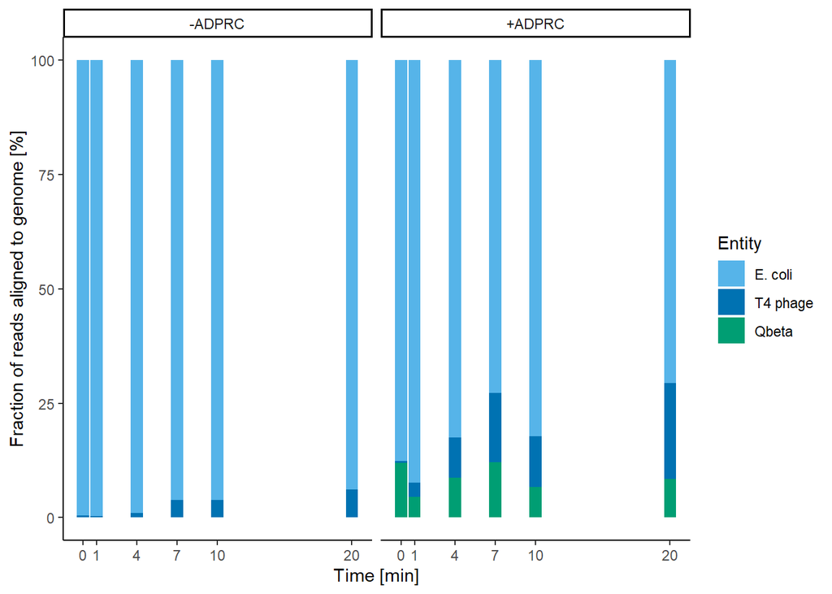

```r
df$Time <- as.numeric(as.character(df$Time))
ggplot(df, aes(x = Time, y = 100*FractionAligned, fill = Entity))+
  geom_bar(stat = "identity", position = "stack")+
 scale_x_continuous(breaks = c(0, 1 , 4, 7, 10, 20 ))+
  facet_wrap(~Type)+
  theme_classic()+
  ylab("Fraction of reads aligned to genome [%]")+
  xlab("Time [min]")+
  scale_fill_manual(values = c( "#56B4E9", "#0072B2", "#009E73"))
```

# 4. Quality control (QC) analysis

## 4.1 Definition of matrix for the following analysis

```r
inp <- normCounts[,7:18]
head(inp)
```

```
##           T0_p         T0_n         T1_p        T1_n         T4_p         T4_n
## 1 5.025019e-04 1.022777e-05 1.225755e-04 7.29698e-06 7.483859e-05 7.162144e-06
## 2 2.194022e-04 1.022777e-05 6.420621e-05 7.29698e-06 6.803508e-06 7.162144e-06
## 3 7.077491e-06 1.022777e-05 5.836928e-06 7.29698e-06 6.803508e-06 7.162144e-06
## 4 7.077491e-06 1.022777e-05 5.836928e-06 7.29698e-06 6.803508e-06 7.162144e-06
## 5 7.077491e-06 1.022777e-05 5.836928e-06 7.29698e-06 6.803508e-06 7.162144e-06
## 6 7.077491e-06 1.022777e-05 5.836928e-06 7.29698e-06 6.803508e-06 7.162144e-06
##           T7_p         T7_n        T10_p        T10_n        T20_p        T20_n
## 1 7.788587e-06 1.132593e-05 5.982065e-05 1.389217e-05 7.974291e-06 1.037743e-05
## 2 7.788587e-06 1.132593e-05 5.438241e-06 1.389217e-05 7.974291e-06 1.037743e-05
## 3 7.788587e-06 1.132593e-05 5.438241e-06 1.389217e-05 7.974291e-06 1.037743e-05
## 4 7.788587e-06 1.132593e-05 5.438241e-06 1.389217e-05 8.771720e-05 1.037743e-05
## 5 7.788587e-06 1.132593e-05 5.438241e-06 1.389217e-05 7.974291e-06 1.037743e-05
## 6 7.788587e-06 1.132593e-05 5.438241e-06 1.389217e-05 7.974291e-06 1.037743e-05
```

```r
tail(inp)
```

```
##              T0_p         T0_n         T1_p        T1_n         T4_p
## 4778 7.077491e-06 1.022777e-05 4.144219e-04 7.29698e-06 1.163400e-03
## 4779 7.077491e-06 1.022777e-05 5.311604e-04 7.29698e-06 6.871543e-04
## 4780 7.077491e-06 1.022777e-05 5.836928e-06 7.29698e-06 6.803508e-06
## 4781 7.077491e-06 1.022777e-05 5.836928e-06 7.29698e-06 6.803508e-06
## 4782 7.077491e-06 1.022777e-05 5.836928e-06 7.29698e-06 6.803508e-06
## 4783 1.201829e-01 1.033005e-03 4.588409e-02 3.72146e-04 8.688760e-02
##              T4_n         T7_p         T7_n        T10_p        T10_n
## 4778 2.936479e-04 8.567445e-05 1.132593e-05 1.685855e-04 1.389217e-05
## 4779 7.162144e-06 7.788587e-06 1.132593e-05 5.438241e-06 1.389217e-05
## 4780 7.162144e-06 7.788587e-06 2.378444e-04 1.685855e-04 1.528139e-04
## 4781 7.162144e-06 8.567445e-05 1.132593e-05 5.438241e-06 1.389217e-05
## 4782 7.162144e-06 8.567445e-05 3.511037e-04 5.982065e-05 2.917355e-04
## 4783 5.085122e-04 1.211203e-01 1.143919e-03 6.673265e-02 9.863440e-04
##             T20_p        T20_n
## 4778 7.974291e-06 1.037743e-05
## 4779 7.974291e-06 1.037743e-05
## 4780 8.771720e-05 1.141517e-04
## 4781 7.974291e-06 1.037743e-05
## 4782 7.974291e-06 1.037743e-05
## 4783 8.517340e-02 1.048120e-03
```

## 4.2 Euclidean distances

We create a heatmap of TPM data for all sample types measuring euclidean distances. Clearly, +ADPRC- and -ADPRC-treated samples show most similiarities among each other. Amongst others due to the abundance of the model RNA (spike-in, Qbeta)

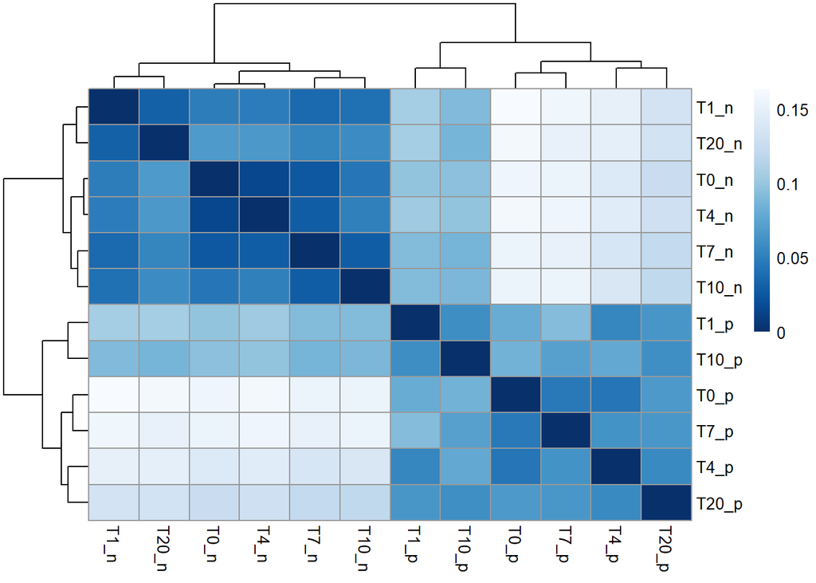

```r
sampleDists <- dist(t(inp))
sampleDistMatrix <- as.matrix(sampleDists)

pheatmap(sampleDistMatrix, cluster_rows = T, cluster_cols = T,
         color = colorRampPalette(rev(brewer.pal(9, "Blues")))(255))
```

## 4.3 Pearson correlation

We create a heatmap of TPM data measuring pearson correlation.

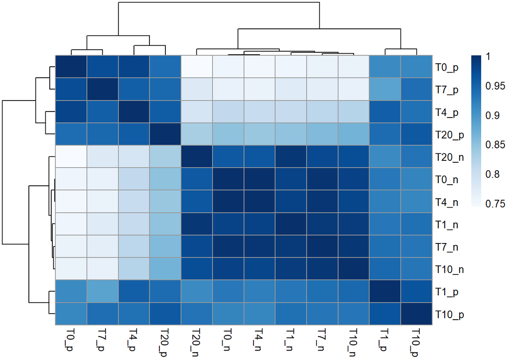

```r
tpm_correlation <- cor(inp, method = "pearson")

ph1 <- pheatmap(tpm_correlation, cluster_rows = T, cluster_cols = T,
         color = colorRampPalette(brewer.pal(9, "Blues"))(255))
```

## 4.4 Principal component analysis (PCA)

We create a matrix consisting of calculated PCs.

```r
tpm_pca <- prcomp(t(as.matrix(inp)), center = TRUE, scale. = TRUE)
```

Then, we determine the variances of each PC (principal component).

```r
pc1 <- summary(tpm_pca)$importance[2,1]*100
pc2 <- summary(tpm_pca)$importance[2,2]*100
pc1
```

```
## [1] 58.386
```

```r
pc2
```

```
## [1] 11.467
```

We configure a dataframe for PC1 and PC2 coordinates for all samples.

```r
pcs_1_2 <- tpm_pca$x[,1:2]
pcs_1_2_sample <- data.frame(cbind(pcs_1_2, rownames(pcs_1_2)))
head(pcs_1_2_sample)
```

```
##                    PC1               PC2   V3
## T0_p -35.4982110884208 -66.5365365718981 T0_p
## T0_n  39.3720709797105  1.95004087948692 T0_n
## T1_p -61.5079142876813 -6.02674386139858 T1_p
## T1_n -19.6820509585705  15.5034988205099 T1_n
## T4_p -39.5220839998836 -6.98603225484416 T4_p
## T4_n -22.1594442422235   16.168921505113 T4_n
```

Then, we transform the format of these values in order to make them calculable.

```r
pcs_1_2_sample$PC1 <- as.numeric(as.character(pcs_1_2_sample$PC1))
pcs_1_2_sample$PC2 <- as.numeric(as.character(pcs_1_2_sample$PC2))
```

We fill the data frame with the annotation for all samples.

```r
sample <- c("T0_p", "T0_n", "T1_p", "T1_n", "T4_p", "T4_n", "T7_p", "T7_n", "T10_p", "T10_n", "T20_p", "T20_n")

time <- c("0","0","1","1","4","4","7","7","10","10","20","20")

type <- c("+ADPRC", "-ADPRC")

pc_annotated <- data.frame(pcs_1_2_sample, type, time)
colnames(pc_annotated) <- c("PC1", "PC2", "Sample", "Type", "Time")
head(pc_annotated)
```

```
##            PC1        PC2 Sample   Type Time
## T0_p -35.49821 -66.536537   T0_p +ADPRC    0
## T0_n  39.37207   1.950041   T0_n -ADPRC    0
## T1_p -61.50791  -6.026744   T1_p +ADPRC    1
## T1_n -19.68205  15.503499   T1_n -ADPRC    1
## T4_p -39.52208  -6.986032   T4_p +ADPRC    4
## T4_n -22.15944  16.168922   T4_n -ADPRC    4
```

We visualize the results of PCA.

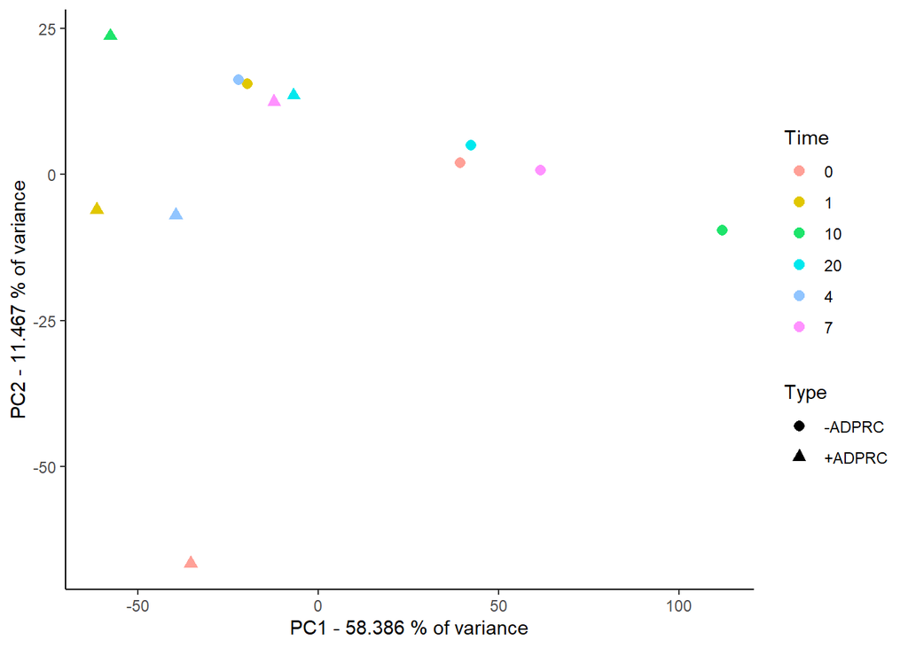

```r
ggplot(pc_annotated, aes(x = PC1, y = PC2, color = Time, shape = Type))+
  geom_point(size= 2.5)+
  scale_color_hue(l=80)+
  theme_classic()+
  xlab(paste0("PC1 - ", pc1, " % of variance"))+
  ylab(paste0("PC2 - ", pc2, " % of variance"))
```

## 4.5 Preparing data for enriched genes

We calculate log2 fold changes (LFC) of two different conditions (+ADPRC and -ADPRC) for each gene and timepoint.

```r
# x defines the normCounts dataframe, n the number of sample pairs.
lfc_calc <- function(x,n){
  df <- x[,1:(n+2)]
  i <- 1
  j <- 3
  while(i<=n*2){
    df[,j] <- log2(x[,n+i]/x[,n+i+1])
    j <- j+1
    i <- i+2
  }
  return(df)
}

lfcs <- lfc_calc(normCounts, 6)
colnames(lfcs) <- c("Gene", "Genome", "LFC_t0", "LFC_t1", "LFC_t4", "LFC_t7", "LFC_t10", "LFC_t20")
head(lfcs)
```

```
##         Gene   Genome    LFC_t0     LFC_t1      LFC_t4     LFC_t7   LFC_t10
## 1 gene-b0001 U00096.3  5.618565  4.0702272  3.38531893 -0.5401956  2.106372
## 2 gene-b0002 U00096.3  4.423014  3.1373414 -0.07411269 -0.5401956 -1.353060
## 3 gene-b0003 U00096.3 -0.531182 -0.3220902 -0.07411269 -0.5401956 -1.353060
## 4 gene-b0004 U00096.3 -0.531182 -0.3220902 -0.07411269 -0.5401956 -1.353060
## 5 gene-b0005 U00096.3 -0.531182 -0.3220902 -0.07411269 -0.5401956 -1.353060
## 6 gene-b0006 U00096.3 -0.531182 -0.3220902 -0.07411269 -0.5401956 -1.353060
##      LFC_t20
## 1 -0.3800206
## 2 -0.3800206
## 3 -0.3800206
## 4  3.0794110
## 5 -0.3800206
## 6 -0.3800206
```

Moreover, we calculate mean expression for each gene and timepoint including +ADPRC and -ADPRC samples.

```r
# x defines the normCounts dataframe, n the number of sample pairs.
means_calc <- function(x,n){
  df <- x[,1:(n+2)]
  i <- 1
  j <- 3
  while(i<=n*2){
    df[,j] <- (x[,n+i]+x[,n+i+1])/2
    j <- j+1
    i <- i+2
  }
  return(df)
}

means <- means_calc(normCounts, 6)
colnames(means) <- c("Gene", "Genome", "Mean_t0", "Mean_t1", "Mean_t4", "Mean_t7", "Mean_t10", "Mean_t20")
head(means)
```

```
##         Gene   Genome      Mean_t0      Mean_t1      Mean_t4      Mean_t7
## 1 gene-b0001 U00096.3 2.563648e-04 6.493623e-05 4.100037e-05 9.557256e-06
## 2 gene-b0002 U00096.3 1.148150e-04 3.575159e-05 6.982826e-06 9.557256e-06
## 3 gene-b0003 U00096.3 8.652632e-06 6.566954e-06 6.982826e-06 9.557256e-06
## 4 gene-b0004 U00096.3 8.652632e-06 6.566954e-06 6.982826e-06 9.557256e-06
## 5 gene-b0005 U00096.3 8.652632e-06 6.566954e-06 6.982826e-06 9.557256e-06
## 6 gene-b0006 U00096.3 8.652632e-06 6.566954e-06 6.982826e-06 9.557256e-06
##       Mean_t10     Mean_t20
## 1 3.685641e-05 9.175859e-06
## 2 9.665205e-06 9.175859e-06
## 3 9.665205e-06 9.175859e-06
## 4 9.665205e-06 4.904731e-05
## 5 9.665205e-06 9.175859e-06
## 6 9.665205e-06 9.175859e-06
```

Then, we combine the data in tables for each timepoint considering that the means and LFC tables have the same origins.

```r
lfc_table_t0 <- data.frame(lfcs[,c(1,2,3)], means[,3])
colnames(lfc_table_t0) <- c("Gene", "Genome", "LFC", "Mean")
lfc_table_t1 <- data.frame(lfcs[,c(1,2,4)], means[,4])
colnames(lfc_table_t1) <- c("Gene", "Genome", "LFC", "Mean")
lfc_table_t4 <- data.frame(lfcs[,c(1,2,5)], means[,5])
colnames(lfc_table_t4) <- c("Gene", "Genome", "LFC", "Mean")
lfc_table_t7 <- data.frame(lfcs[,c(1,2,6)], means[,6])
colnames(lfc_table_t7) <- c("Gene", "Genome", "LFC", "Mean")
lfc_table_t10 <- data.frame(lfcs[,c(1,2,7)], means[,7])
colnames(lfc_table_t10) <- c("Gene", "Genome", "LFC", "Mean")
lfc_table_t20 <- data.frame(lfcs[,c(1,2,8)], means[,8])
colnames(lfc_table_t20) <- c("Gene", "Genome", "LFC", "Mean")
```

## 5. Creating plots with labeled enriched genes for each timepoint.

First, we optimize the format of LFC-mean tables by addition of the gene symbols. Then, we create the plot.

We load the annotation table that contains the gene symbols to assign gene symbols to the geneids.

```r
annotation_table <- as.data.frame(read.delim("Q:/Lab Members/Maik/Project_NAD-captureSeq_final_data/Final_analysis_ONT-data/Reference_genomes/NAD_captureSeq_K12_feature_table.tsv"))
annotation_table_all <- annotation_table[which(annotation_table$type == "gene"),]
```

#### 0 min post-infection

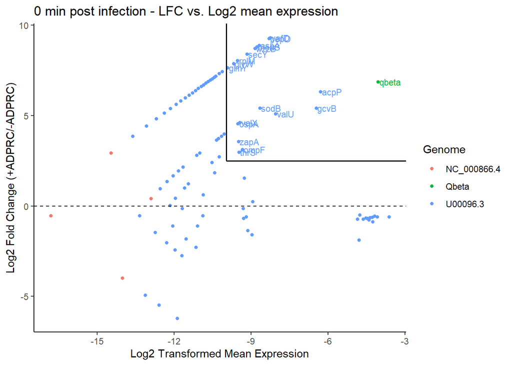

```r
# x represents the lfc table containing gene, genome, lfc and mean information for each gene and an individual time point
# the annotation table is added via the "annotation_table_all" variable
# lfc_thr and mean_thr are the self-chosen thresholds for LFC and mean values
# "time_point" should match the time point from x

plot_lfc_vs_mean <- function(x=lfc_table_t0, annotation_table_all, lfc_thr=2.5, mean_thr=0.001, time_point="0 min post infection"){
  df_genes <- annotation_table_all$gene[match(x[,1], annotation_table_all$ID)]
  df_edit <- x
  df_edit$Gene <- df_genes

  enr_plot <- ggplot(df_edit, aes(x = log2(Mean), y = LFC))+
    geom_point(size = 1.3, aes(color = Genome))+
    theme_classic()+
    ylab("Log2 Fold Change (+ADPRC/-ADPRC)")+
    xlab("Log2 Transformed Mean Expression")+
    geom_hline(yintercept = 0, linetype = "dashed")+
    geom_segment(aes(x = log2(mean_thr), y = lfc_thr, xend = log2(0.001), yend = +Inf), linewidth = 0.7)+
    geom_segment(aes(x = log2(mean_thr) , y = lfc_thr, xend = +Inf, yend = 2.5), linewidth = 0.7)+
    ggtitle(paste0(time_point," - LFC vs. Log2 mean expression"))+
    geom_text(data=subset(df_edit, LFC >=lfc_thr & Mean >= mean_thr), aes(label= Gene, color = Genome), hjust = 0, nudge_x = 0.05, size = 3, show.legend = F)
  return(enr_plot)
}


plot_lfc_vs_mean(lfc_table_t0, annotation_table_all, 2.5, 0.001, "0 min post infection")
```

#### 1 min post-infection

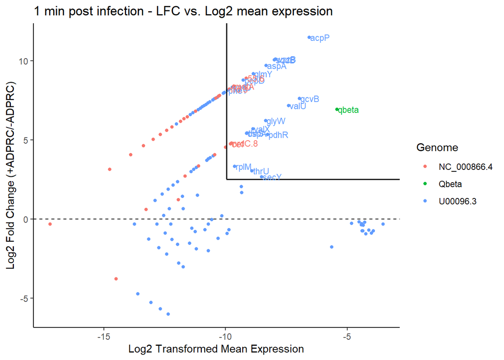

```r
plot_lfc_vs_mean(lfc_table_t1, annotation_table_all, 2.5, 0.001, "1 min post infection")
```

#### 4 min post-infection

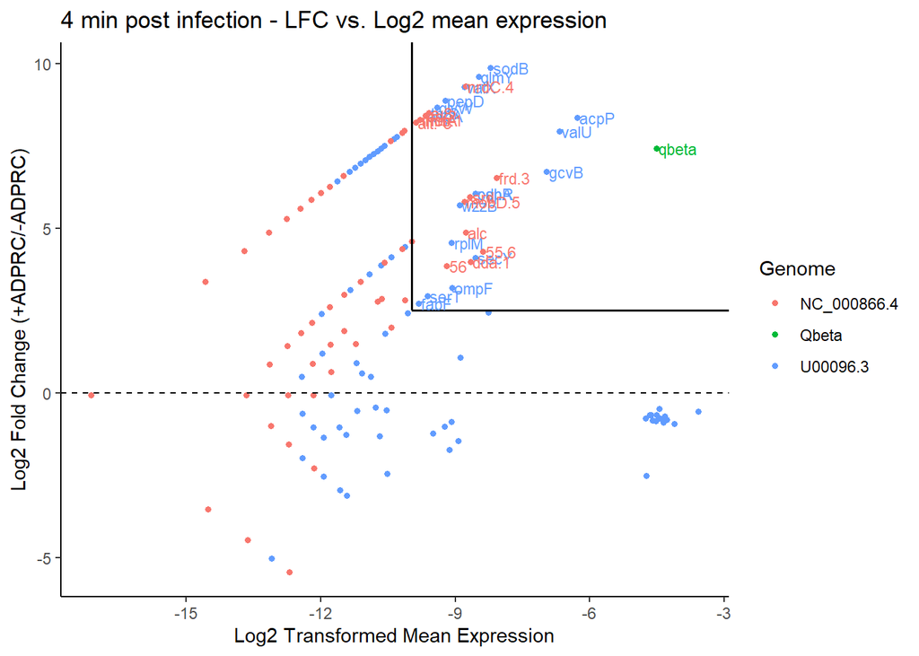

```r
plot_lfc_vs_mean(lfc_table_t4, annotation_table_all, 2.5, 0.001, "4 min post infection")
```

#### 7 min post-infection

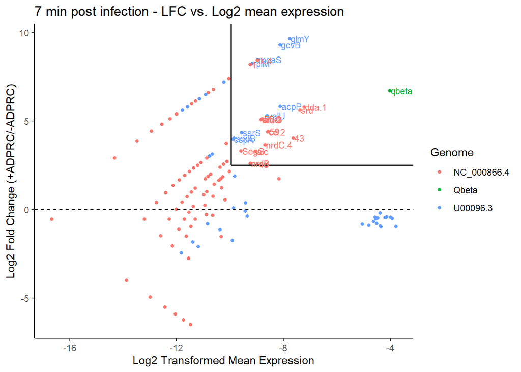

```r
plot_lfc_vs_mean(lfc_table_t7, annotation_table_all, 2.5, 0.001, "7 min post infection")
```

#### 10 min post-infection

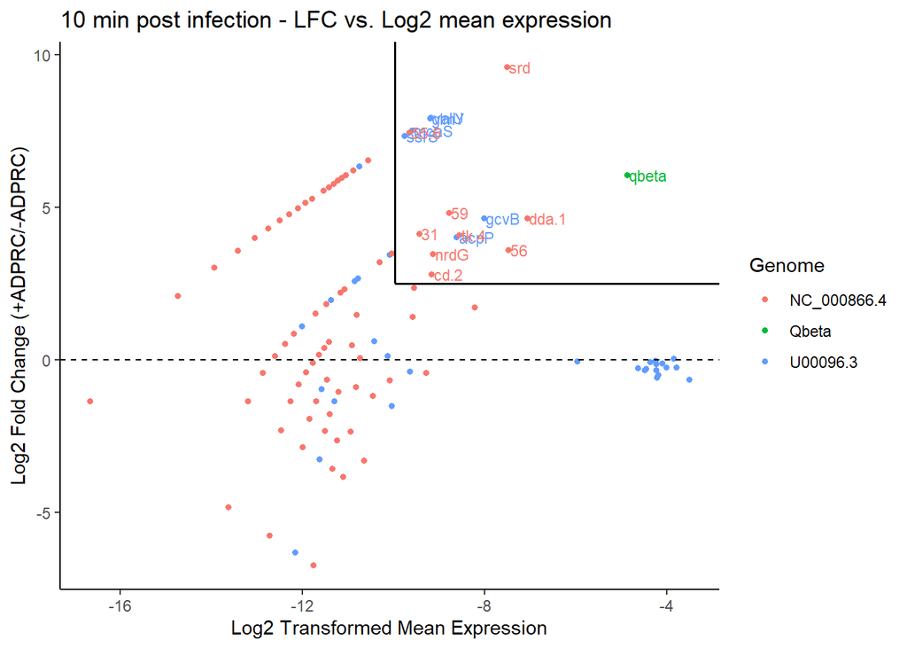

```r
plot_lfc_vs_mean(lfc_table_t10, annotation_table_all, 2.5, 0.001, "10 min post infection")
```

#### 20 min post-infection

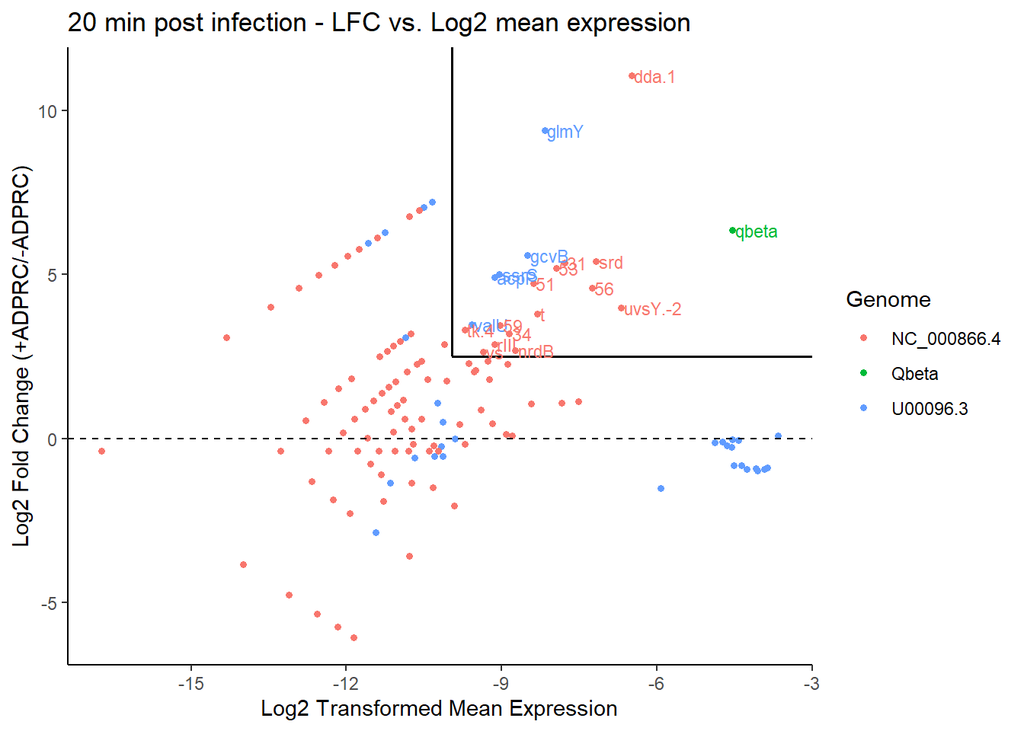

```r
plot_lfc_vs_mean(lfc_table_t20, annotation_table_all, 2.5, 0.001, "20 min post infection")
```

# 6. Filtering of the significantly enriched and expressed genes

Filtering of the LFC tables based on these criteria in order to extract those genes specifically.

```r
df_filtered <- lfc_table_t0 %>% filter(Mean >= 0.0005) %>% filter(LFC >= 2.5)
df_filtered1 <- lfc_table_t1 %>% filter(Mean >= 0.0005) %>% filter(LFC >= 2.5)
df_filtered4 <- lfc_table_t4 %>% filter(Mean >= 0.0005) %>% filter(LFC >= 2.5)
df_filtered7 <- lfc_table_t7 %>% filter(Mean >= 0.0005) %>% filter(LFC >= 2.5)
df_filtered10 <- lfc_table_t10 %>% filter(Mean >= 0.0005) %>% filter(LFC >= 2.5)
df_filtered20 <- lfc_table_t20 %>% filter(Mean >= 0.0005) %>% filter(LFC >= 2.5)
```

The adjusted table for timepoint 0 is for instance:

```r
# x = filtered genes; annotation_table_all matches geneids to symbols
gene_annotation <- function(x, annotation_table_all){
  gene_symbols <- annotation_table_all$gene[match(x[,1], annotation_table_all$ID)]
  df_final <- data.frame(x, gene_symbols)
  return(df_final)
}
df_final <- gene_annotation(df_filtered, annotation_table_all)
head(df_final)
```

```
##         Gene   Genome      LFC         Mean gene_symbols
## 1 gene-b0081 U00096.3 3.980930 0.0009444779         mraZ
## 2 gene-b0126 U00096.3 7.440362 0.0008933391          can
## 3 gene-b0154 U00096.3 6.608369 0.0005040770         hemL
## 4 gene-b0209 U00096.3 9.315875 0.0032642987         yafD
## 5 gene-b0237 U00096.3 9.268100 0.0031581363         pepD
## 6 gene-b0755 U00096.3 3.730486 0.0008029281         gpmA
```

The adjusted table for timepoint 1, and so on…

```r
df_final1 <- gene_annotation(df_filtered1, annotation_table_all)
df_final4 <- gene_annotation(df_filtered4, annotation_table_all)
df_final7 <- gene_annotation(df_filtered7, annotation_table_all)
df_final10 <- gene_annotation(df_filtered10, annotation_table_all)
df_final20 <- gene_annotation(df_filtered20, annotation_table_all)
```

These tables can be exported as csv files.

```r
#write_excel_csv(df_final, paste0("ONTrun_061_enriched_genes_", time, "_unclassified.csv"), delim = ";")
#write_excel_csv(df_final1, paste0("ONTrun_061_enriched_genes_", time1, "_unclassified.csv"), delim = ";")
#write_excel_csv(df_final4, paste0("ONTrun_061_enriched_genes_", time4, "_unclassified.csv"), delim = ";")
#write_excel_csv(df_final7, paste0("ONTrun_061_enriched_genes_", time7, "_unclassified.csv"), delim = ";")
#write_excel_csv(df_final10, paste0("ONTrun_061_enriched_genes_", time10, "_unclassified.csv"), delim = ";")
#write_excel_csv(df_final20, paste0("ONTrun_061_enriched_genes_", time20, "_unclassified.csv"), delim = ";")
```

# 7. Filtering of the abundant but non-enriched genes from LFC tables

These could be the rRNA genes that we found to be in the background. Thus, LFC is somewhere in between -1 and 1.

```r
# t0
df_filteredb <- lfc_table_t0 %>% filter(Mean >= 0.03) %>% filter(LFC <= 1) %>% filter(LFC >= -1)
# t1
df_filtered1b <- lfc_table_t1 %>% filter(Mean >= 0.03) %>% filter(LFC <= 1) %>% filter(LFC >= -1)
# t4
df_filtered4b <- lfc_table_t4 %>% filter(Mean >= 0.03) %>% filter(LFC <= 1) %>% filter(LFC >= -1)
# t7
df_filtered7b <- lfc_table_t7 %>% filter(Mean >= 0.03) %>% filter(LFC <= 1) %>% filter(LFC >= -1)
# t10
df_filtered10b <- lfc_table_t10 %>% filter(Mean >= 0.03) %>% filter(LFC <= 1) %>% filter(LFC >= -1)
# t20
df_filtered20b <- lfc_table_t20 %>% filter(Mean >= 0.03) %>% filter(LFC <= 1) %>% filter(LFC >= -1)
```

Here, we add gene symbols and gene types to the newly filtered LFC tables for each timepoint. We take the function from before and add gene biotype feature in order to get a better insight into the nature of the background.

```r
# x = filtered genes; annotation_table_all matches geneids to symbols
gene_annotation_background <- function(x, annotation_table_all){
  gene_symbols <- annotation_table_all$gene[match(x[,1], annotation_table_all$ID)]
  gene_types <- annotation_table_all$gene_biotype[match(x[,1], annotation_table_all$ID)]
  df_final <- data.frame(x, gene_symbols, gene_types)
  return(df_final)
}
df_final_back <- gene_annotation_background(df_filteredb, annotation_table_all)
head(df_final_back)
```

```
##         Gene   Genome        LFC       Mean gene_symbols gene_types
## 1 gene-b0201 U00096.3 -0.8739049 0.05233483         rrsH       rRNA
## 2 gene-b0204 U00096.3 -0.6968421 0.04573446         rrlH       rRNA
## 3 gene-b2589 U00096.3 -0.6399989 0.04853459         rrlG       rRNA
## 4 gene-b2591 U00096.3 -0.6822869 0.04591140         rrsG       rRNA
## 5 gene-b3275 U00096.3 -0.4972426 0.03670358         rrlD       rRNA
## 6 gene-b3278 U00096.3 -0.7229442 0.04024791         rrsD       rRNA
```

Again, this can be performed for each time point yielding the background genes for each time point.

```r
# t1
df_final_back1 <- gene_annotation_background(df_filtered1b, annotation_table_all)
# t4
df_final_back4 <- gene_annotation_background(df_filtered4b, annotation_table_all)
# t7
df_final_back7 <- gene_annotation_background(df_filtered7b, annotation_table_all)
# t10
df_final_back10 <- gene_annotation_background(df_filtered10b, annotation_table_all)
# t20
df_final_back20 <- gene_annotation_background(df_filtered20b, annotation_table_all)
```

# 8. Overlaps between different timepoints of T4 phage infection

## 8.1 Plotting of the overlaps between NAD-RNAs of different time points

Therefore, we use the filtered NAD-RNAs, which fulfill the two criteria (Mean >= 0.0005, LFC >= 2.5): t0_filtered, t1_filtered, t4_filtered, t7_filtered, t10_filtered, t20_filtered

```r
t0_filtered <- (lfc_table_t0 %>% filter(Mean >= 0.0005) %>% filter(LFC >= 2.5))[,1:2]
t1_filtered <- (lfc_table_t1 %>% filter(Mean >= 0.0005) %>% filter(LFC >= 2.5))[,1:2]
t4_filtered <- (lfc_table_t4 %>% filter(Mean >= 0.0005) %>% filter(LFC >= 2.5))[,1:2]
t7_filtered <- (lfc_table_t7 %>% filter(Mean >= 0.0005) %>% filter(LFC >= 2.5))[,1:2]
t10_filtered <- (lfc_table_t10 %>% filter(Mean >= 0.0005) %>% filter(LFC >= 2.5))[,1:2]
t20_filtered <- (lfc_table_t20 %>% filter(Mean >= 0.0005) %>% filter(LFC >= 2.5))[,1:2]
```

Now, we create a list containing NAD-RNA geneids from t4, t7, t10, t20

```r
x <- list(t4_filtered[,1], t7_filtered[,1], t10_filtered[,1], t20_filtered[,1])
```

We use Venn diagram for showing the overlaps of NAD-RNAs between different time points.

For this, library(VennDiagram) and a helper-function are necessary.

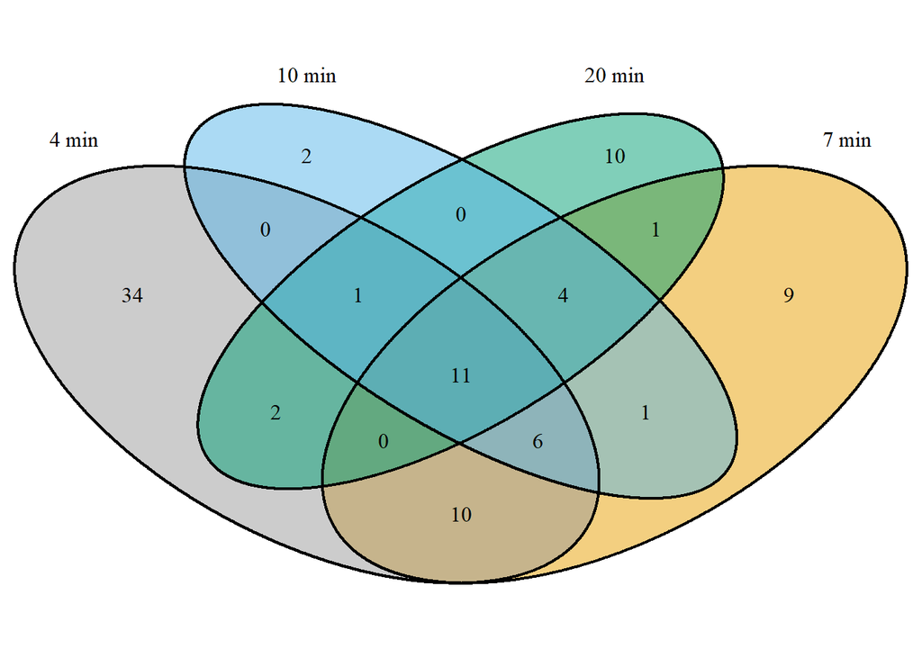

```r
display_venn <- function(x, ...){
  library(VennDiagram)
  grid.newpage()
  venn_object <- venn.diagram(x, filename = NULL, ...)
  grid.draw(venn_object)
}

display_venn(
  x,
  category.names = c("4 min" , "7 min" , "10 min", "20 min"),
  fill = c("#999999", "#E69F00", "#56B4E9", "#009E73")
)
```

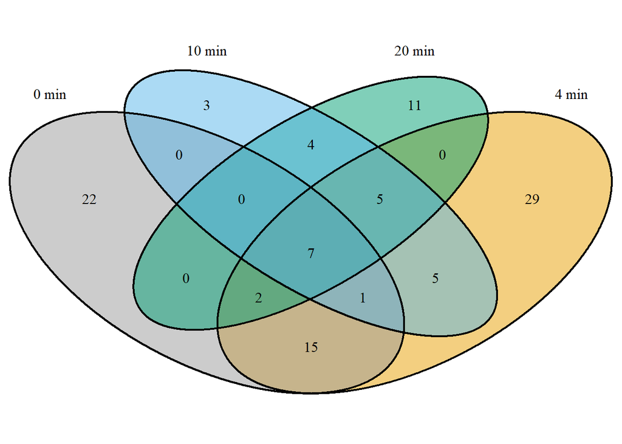

```r
# We can create a different set of geneids from different time points, e.g. t0, t4, t10, t20.
x1 <- list(t0_filtered[,1], t4_filtered[,1], t10_filtered[,1], t20_filtered[,1])

display_venn1 <- function(x, ...){
  library(VennDiagram)
  grid.newpage()
  venn_object <- venn.diagram(x, filename = NULL, ...)
  grid.draw(venn_object)
}

display_venn1(
  x1,
  category.names = c("0 min" , "4 min" , "10 min", "20 min"),
  fill = c("#999999", "#E69F00", "#56B4E9", "#009E73")
)
```

# 10. Plotting of fractions of NAD-RNAs per entity (*E. coli* or T4 phage) comparing different timepoints

## Addition of functions of the filtered NAD-RNAs from the annotation table

We add the product name to each gene from the NAD-RNAs filtered from the LFC Table in order to get an idea of the functions they encode.

```r
t0_functions <- annotation_table$product[match(t0_filtered[,1], annotation_table$Parent)]
t1_functions <- annotation_table$product[match(t1_filtered[,1], annotation_table$Parent)]
t4_functions <- annotation_table$product[match(t4_filtered[,1], annotation_table$Parent)]
t7_functions <- annotation_table$product[match(t7_filtered[,1], annotation_table$Parent)]
t10_functions <- annotation_table$product[match(t10_filtered[,1], annotation_table$Parent)]
t20_functions <- annotation_table$product[match(t20_filtered[,1], annotation_table$Parent)]
```

## We define all the required variables and create a graph representing the absolute number of NAD-capped RNAs detected in each of both genomes

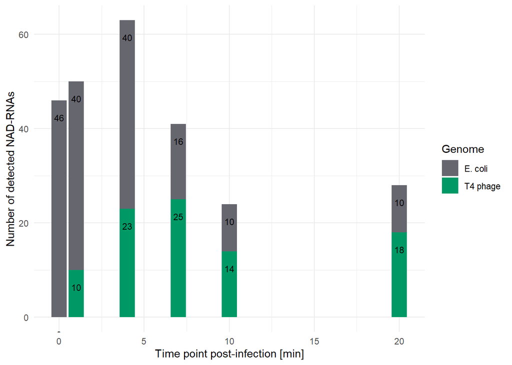

```r
# Extract phage NAD-RNAs for each time point
t0_phage <- nrow(t0_filtered[which(t0_filtered[,2] == "NC_000866.4"),])
t1_phage <- nrow(t1_filtered[which(t1_filtered[,2] == "NC_000866.4"),])
t4_phage <- nrow(t4_filtered[which(t4_filtered[,2] == "NC_000866.4"),])
t7_phage <- nrow(t7_filtered[which(t7_filtered[,2] == "NC_000866.4"),])
t10_phage <- nrow(t10_filtered[which(t10_filtered[,2] == "NC_000866.4"),])
t20_phage <- nrow(t20_filtered[which(t20_filtered[,2] == "NC_000866.4"),])

# Extract coli NAD-RNAs for each time point
t0_coli <- nrow(t0_filtered[which(t0_filtered[,2] == "U00096.3"),])
t1_coli <- nrow(t1_filtered[which(t1_filtered[,2] == "U00096.3"),])
t4_coli <- nrow(t4_filtered[which(t4_filtered[,2] == "U00096.3"),])
t7_coli <- nrow(t7_filtered[which(t7_filtered[,2] == "U00096.3"),])
t10_coli <- nrow(t10_filtered[which(t10_filtered[,2] == "U00096.3"),])
t20_coli <- nrow(t20_filtered[which(t20_filtered[,2] == "U00096.3"),])

# Merge the information in a data frame
Coli <- c(t0_coli, t1_coli, t4_coli, t7_coli, t10_coli, t20_coli)
phage <- c(t0_phage, t1_phage, t4_phage, t7_phage, t10_phage, t20_phage)
time_ <- c(0, 1, 4, 7, 10, 20)

df_ <- data.frame(time_, Coli, phage)
colnames(df_) <- c("Time", "E. coli", "T4 phage")

# Melt the data frame for plotting
df_final_ <- melt(df_, id = c("Time"))
colnames(df_final_) <- c("Time", "Genome", "value")

# Create a barplot
ggplot(df_final_, aes(fill=Genome, y=value, x=Time)) +
  geom_bar(position="stack", stat="identity")+
  xlab("Time point post-infection [min]")+
  ylab("Number of detected NAD-RNAs")+
  theme_minimal()+
  scale_fill_manual(values = c("#66666F", "#009966"))+
  geom_text(aes(label = value), size = 3, hjust = 0.5, vjust = 3, position = "stack")
```

## 11. Creation of the final list of enriched transcripts

Here, we create a large table containing all genes with NAD-capped transcripts, the timepoints they are detected, the entity they come from and their function.

We start with the extraction of all significant NAD-capped RNAs per timepoint as it was done above.

```r
t0_filtered <- (lfc_table_t0 %>% filter(Mean >= 0.0005) %>% filter(LFC >= 2.5))[,1]
t1_filtered <- (lfc_table_t1 %>% filter(Mean >= 0.0005) %>% filter(LFC >= 2.5))[,1]
t4_filtered <- (lfc_table_t4 %>% filter(Mean >= 0.0005) %>% filter(LFC >= 2.5))[,1]
t7_filtered <- (lfc_table_t7 %>% filter(Mean >= 0.0005) %>% filter(LFC >= 2.5))[,1]
t10_filtered <- (lfc_table_t10 %>% filter(Mean >= 0.0005) %>% filter(LFC >= 2.5))[,1]
t20_filtered <- (lfc_table_t20 %>% filter(Mean >= 0.0005) %>% filter(LFC >= 2.5))[,1]
```

Then we again generate a list of all NAD-RNAs and remove duplicates.

```r
NADcappedRNAs <- unique(c(t0_filtered, t1_filtered, t4_filtered, t7_filtered, t10_filtered, t20_filtered))
```

Finally, we create a table containing all needed information.

NAD-RNAs will be searched at each timepoint using a loop. + or - will be added in the table depending on the presence or absence of that RNA, respectively.

```r
t0 <- c(1:length(NADcappedRNAs))
i <- 1
while (i <= length(NADcappedRNAs)){
  if (NADcappedRNAs[i] %in% t0_filtered){
    t0[i] <- "+"
  } else {
    t0[i] <- "-"
  }
  i <- i+1
}

t1 <- c(1:length(NADcappedRNAs))
i <- 1
while (i <= length(NADcappedRNAs)){
  if (NADcappedRNAs[i] %in% t1_filtered){
    t1[i] <- "+"
  } else {
    t1[i] <- "-"
  }
  i <- i+1
}

t4 <- c(1:length(NADcappedRNAs))
i <- 1
while (i <= length(NADcappedRNAs)){
  if (NADcappedRNAs[i] %in% t4_filtered){
    t4[i] <- "+"
  } else {
    t4[i] <- "-"
  }
  i <- i+1
}

t7 <- c(1:length(NADcappedRNAs))
i <- 1
while (i <= length(NADcappedRNAs)){
  if (NADcappedRNAs[i] %in% t7_filtered){
    t7[i] <- "+"
  } else {
    t7[i] <- "-"
  }
  i <- i+1
}

t10 <- c(1:length(NADcappedRNAs))
i <- 1
while (i <= length(NADcappedRNAs)){
  if (NADcappedRNAs[i] %in% t10_filtered){
    t10[i] <- "+"
  } else {
    t10[i] <- "-"
  }
  i <- i+1
}

t20 <- c(1:length(NADcappedRNAs))
i <- 1
while (i <= length(NADcappedRNAs)){
  if (NADcappedRNAs[i] %in% t20_filtered){
    t20[i] <- "+"
  } else {
    t20[i] <- "-"
  }
  i <- i+1
}
```

Finally, we create a large table containing all needed information and sort the table according to the geneids.

```r
# Create the data frame
final_df <- data.frame(NADcappedRNAs, normCounts$Chr[NADcappedRNAs], t0, t1, t4, t7, t10, t20, annotation_table$gene[match(NADcappedRNAs, annotation_table$Parent)], annotation_table$gene_biotype[match(NADcappedRNAs, annotation_table$ID)], annotation_table$product[match(NADcappedRNAs, annotation_table$Parent)])
# Rename the columns
colnames(final_df) <- c("Geneid", "Entity", "t0", "t1", "t4", "t7", "t10", "t20", "Gene", "Gene Type", "Funtion/Product")
# Order based on Geneid
final_df_ordered <- final_df[order(final_df$Geneid),]

head(final_df_ordered)
```

```
##        Geneid   Entity t0 t1 t4 t7 t10 t20 Gene      Gene Type
## 69 gene-b0024 U00096.3  -  -  +  -   -   - yaaY protein_coding
## 1  gene-b0081 U00096.3  +  +  -  -   -   - mraZ protein_coding
## 48 gene-b0113 U00096.3  -  +  +  -   -   - pdhR protein_coding
## 2  gene-b0126 U00096.3  +  +  -  -   -   -  can protein_coding
## 3  gene-b0154 U00096.3  +  -  -  -   -   - hemL protein_coding
## 4  gene-b0209 U00096.3  +  +  +  -   -   - yafD protein_coding
##                                                        Funtion/Product
## 69                              DUF2575 domain-containing protein YaaY
## 1                           DNA-binding transcriptional repressor MraZ
## 48                     DNA-binding transcriptional dual regulator PdhR
## 2                                                 carbonic anhydrase 2
## 3                           glutamate-1-semialdehyde 2%2C1-aminomutase
## 4  endonuclease/exonuclease/phosphatase domain-containing protein YafD
```